# Introduction to Computer Vision: Plant Seedlings Classification

## Problem Statement

### Context

In recent times, the field of agriculture has been in urgent need of modernizing, since the amount of manual work people need to put in to check if plants are growing correctly is still highly extensive. Despite several advances in agricultural technology, people working in the agricultural industry still need to have the ability to sort and recognize different plants and weeds, which takes a lot of time and effort in the long term. The potential is ripe for this trillion-dollar industry to be greatly impacted by technological innovations that cut down on the requirement for manual labor, and this is where Artificial Intelligence can actually benefit the workers in this field, as **the time and energy required to identify plant seedlings will be greatly shortened by the use of AI and Deep Learning.** The ability to do so far more efficiently and even more effectively than experienced manual labor, could lead to better crop yields, the freeing up of human inolvement for higher-order agricultural decision making, and in the long term will result in more sustainable environmental practices in agriculture as well.

### Objective

The aim of this project is to Build a Convolutional Neural Netowrk to classify plant seedlings into their respective categories.

### Data Dictionary

The Aarhus University Signal Processing group, in collaboration with the University of Southern Denmark, has recently released a dataset containing **images of unique plants belonging to 12 different species.**

- The dataset can be download from Olympus.
- The data file names are:
  - images.npy
  - Labels.csv
- Due to the large volume of data, the images were converted to the images.npy file and the labels are also put into Labels.csv, so that you can work on the data/project seamlessly without having to worry about the high data volume.
- The goal of the project is to create a classifier capable of determining a plant's species from an image.

**List of Species**

- Black-grass
- Charlock
- Cleavers
- Common Chickweed
- Common Wheat
- Fat Hen
- Loose Silky-bent
- Maize
- Scentless Mayweed
- Shepherds Purse
- Small-flowered Cranesbill
- Sugar beet

### **Note: Please use GPU runtime on Google Colab to execute the code faster.**

## Importing necessary libraries

```python
# Installing the libraries with the specified version.
!pip install tensorflow==2.15.0 scikit-learn==1.2.2 seaborn==0.13.1 matplotlib==3.7.1 numpy==1.25.2 pandas==2.0.3 opencv-python==4.8.0.76 -q --user
```

**Note**: *After running the above cell, kindly restart the notebook kernel and run all cells sequentially from the start again.*

```python
import math
import os
import random
import warnings

import cv2
from google.colab.patches import cv2_imshow

import matplotlib.pyplot as plt
import numpy as np
import pandas as pd
import seaborn as sns

# Scikit-learn modules
from sklearn import preprocessing
from sklearn.metrics import confusion_matrix
from sklearn.model_selection import train_test_split
from sklearn.preprocessing import LabelBinarizer

# TensorFlow modules
import tensorflow as tf
from tensorflow.keras import backend
from tensorflow.keras.layers import BatchNormalization, Conv2D, Dense, Dropout, Flatten, MaxPooling2D
from tensorflow.keras.models import Sequential
from tensorflow.keras.optimizers import Adam, SGD
from tensorflow.keras.preprocessing.image import ImageDataGenerator

# Keras callbacks
from keras.callbacks import ReduceLROnPlateau

# Ignore warnings
warnings.filterwarnings('ignore')
```

## Loading the dataset

```python
# Get data from gdrive
from google.colab import drive
drive.mount('/content/drive')
```

```python
# Paths for data
# images_data_path = "/content/drive/MyDrive/AIML-Certification/AIML-training/Computer Vision/Wk2-Trasnsfer Learning/Project- plant species/images.npy"
# labels_data_path = "/content/drive/MyDrive/AIML-Certification/AIML-training/Computer Vision/Wk2-Trasnsfer Learning/Project- plant species/Labels.csv"

images_data_path = "/content/drive/MyDrive/aiml/images.npy"
labels_data_path = "/content/drive/MyDrive/aiml/Labels.csv"
```

```python
#images data to np array
images = np.load(images_data_path)
```

```python
#labels data to np array
labels = pd.read_csv(labels_data_path)
```

## Data Overview

### Understand the shape of the dataset

```python
# images data shape
images.shape
```

```
(4750, 128, 128, 3)
```

```python
# labels data shape
labels.shape
```

```
(4750, 1)
```

## Exploratory Data Analysis

- EDA is an important part of any project involving data.
- It is important to investigate and understand the data better before building a model with it.
- A few questions have been mentioned below which will help you understand the data better.
- A thorough analysis of the data, in addition to the questions mentioned below, should be done.
1. How are these different category plant images different from each other?
2. Is the dataset provided an imbalance? (Check with using bar plots)

```python
# Common function to plot or visualize images
def plot_images(images,labels):
  num_classes=10
  categories=np.unique(labels)
  keys=dict(labels['Label'])
  rows = 3
  cols = 4
  fig = plt.figure(figsize=(10, 8))
  for i in range(cols):
      for j in range(rows):
          random_index = np.random.randint(0, len(labels))
          ax = fig.add_subplot(rows, cols, i * rows + j + 1)
          ax.imshow(images[random_index, :])
          ax.set_title(keys[random_index])
  plt.show()
```

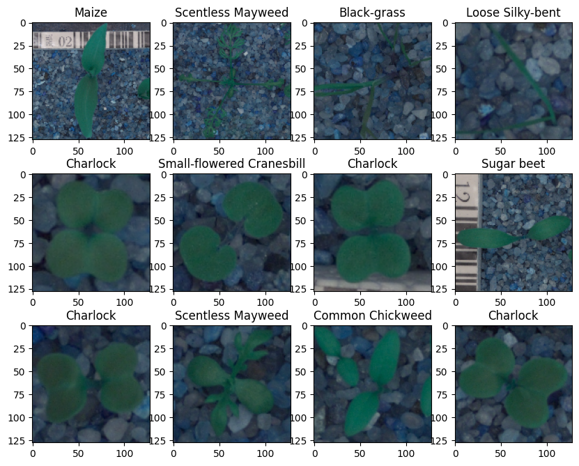

```python
plot_images(images, labels)
```

```python
labels.info()
```

```
<class 'pandas.core.frame.DataFrame'>
RangeIndex: 4750 entries, 0 to 4749
Data columns (total 1 columns):
 #   Column  Non-Null Count  Dtype
---  ------  --------------  -----
 0   Label   4750 non-null   object
dtypes: object(1)
memory usage: 37.2+ KB
```

[output not shown]

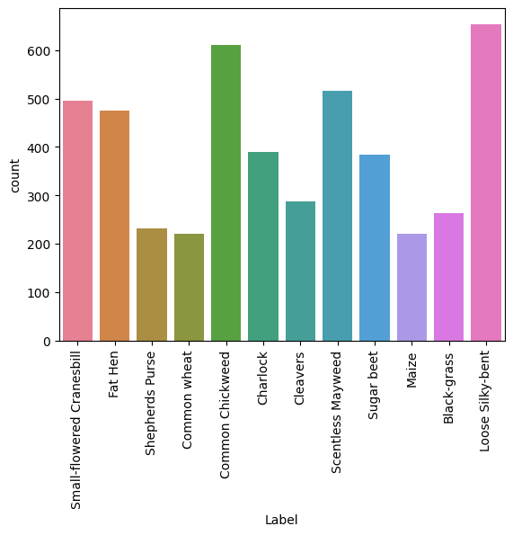

```python
# check the target variable
sns.countplot(x=labels['Label'], hue=labels['Label'])
plt.xticks(rotation='vertical')
```

## Data Pre-Processing

### Convert the BGR images to RGB images.

```python
for image in range(len(images)):
  images[image] = cv2.cvtColor(images[image], cv2.COLOR_BGR2RGB)
```

### Resize the images

As the size of the images is large, it may be computationally expensive to train on these larger images; therefore, it is preferable to reduce the image size from 128 to 64.

```python
# Decrease image size
images_decreased=[]
height = 64
width =  64
dimensions = (width, height)
for i in range(len(images)):
  images_decreased.append( cv2.resize(images[i], dimensions, interpolation=cv2.INTER_LINEAR))
```

```python
# before resizing
plt.imshow(images[3])
```

[output not shown]

```python
# After resizing
plt.imshow(images_decreased[3])
```

[output not shown]

### Data Preparation for Modeling

- Before you proceed to build a model, you need to split the data into train, test, and validation to be able to evaluate the model that you build on the train data
- You'll have to encode categorical features and scale the pixel values.
- You will build a model using the train data and then check its performance

**Split the dataset**

```python
X_temp, X_test, y_temp, y_test = train_test_split(np.array(images_decreased),labels, test_size=0.1, random_state=42, stratify=labels)
```

```python
y_temp.shape, y_test.shape, X_temp.shape, X_test.shape
```

```
((4275, 1), (475, 1), (4275, 64, 64, 3), (475, 64, 64, 3))
```

```python
X_train, X_val, y_train, y_val = train_test_split(X_temp, y_temp, test_size=0.2, random_state=42, stratify=y_temp)
```

```python
#check shapes of train and test and validation data sets
print(X_train.shape,y_train.shape)
print(X_val.shape,y_val.shape)
print(X_test.shape,y_test.shape)
```

```
(3420, 64, 64, 3) (3420, 1)
(855, 64, 64, 3) (855, 1)
(475, 64, 64, 3) (475, 1)
```

### Encode the target labels

```python
# encoding the lables as onehot encoding
label_binarizer = LabelBinarizer()
```

```python
y_train_encoded = label_binarizer.fit_transform(y_train)
```

```python
y_val_encoded=label_binarizer.transform(y_val)
```

```python
y_test_encoded=label_binarizer.transform(y_test)
```

```python
y_train_encoded.shape,y_val_encoded.shape,y_test_encoded.shape
```

```
((3420, 12), (855, 12), (475, 12))
```

### Data Normalization

```python
X_train_normalized = X_train.astype('float32')/255.0
X_val_normalized = X_val.astype('float32')/255.0
X_test_normalized = X_test.astype('float32')/255.0
```

```python
X_train_normalized.shape, X_val_normalized.shape, X_test_normalized.shape
```

```
((3420, 64, 64, 3), (855, 64, 64, 3), (475, 64, 64, 3))
```

## Model Building

```python
# clear session
backend.clear_session()
```

```python
# setup for consistent randomness
np.random.seed(42)
random.seed(42)
tf.random.set_seed(42)
```

```python
# Get sequential model
model1 = Sequential()

# 1st c layer with 128 filters use 'same' for padding
model1.add(Conv2D(128, (3, 3), activation='relu', padding="same", input_shape=(64, 64, 3)))

# 2nd layer
model1.add(MaxPooling2D((2, 2), padding = 'same'))

# 3rd layer
model1.add(Conv2D(64, (3, 3), activation='relu', padding="same"))
model1.add(MaxPooling2D((2, 2), padding = 'same'))

# 4th layer
model1.add(Conv2D(64, (3, 3), activation='relu', padding="same"))
model1.add(MaxPooling2D((2, 2), padding = 'same'))

# add flatten layer
model1.add(Flatten())

# fully connected layer with 16 neurons
model1.add(Dense(16, activation='relu'))
model1.add(Dropout(0.3))

#out layer with 12 neurons
model1.add(Dense(12, activation='softmax'))

# compile the model using adam optimizer and loss function cate crossentropy
opt=Adam(lr=0.001)
model1.compile(optimizer=opt, loss='categorical_crossentropy', metrics=['accuracy'])

# model summary
model1.summary()
```

```
WARNING:absl:`lr` is deprecated in Keras optimizer, please use `learning_rate` or use the legacy optimizer, e.g.,tf.keras.optimizers.legacy.Adam.
```

```
Model: "sequential"
_________________________________________________________________
 Layer (type)                Output Shape              Param #
=================================================================
 conv2d (Conv2D)             (None, 64, 64, 128)       3584

 max_pooling2d (MaxPooling2  (None, 32, 32, 128)       0
 D)

 conv2d_1 (Conv2D)           (None, 32, 32, 64)        73792

 max_pooling2d_1 (MaxPoolin  (None, 16, 16, 64)        0
 g2D)

 conv2d_2 (Conv2D)           (None, 16, 16, 64)        36928

 max_pooling2d_2 (MaxPoolin  (None, 8, 8, 64)          0
 g2D)

 flatten (Flatten)           (None, 4096)              0

 dense (Dense)               (None, 16)                65552

 dropout (Dropout)           (None, 16)                0

 dense_1 (Dense)             (None, 12)                204

=================================================================
Total params: 180060 (703.36 KB)
Trainable params: 180060 (703.36 KB)
Non-trainable params: 0 (0.00 Byte)
_________________________________________________________________
```

```python
X_train_normalized.shape, y_train_encoded.shape, X_val_normalized.shape, y_val_encoded.shape
```

```
((3420, 64, 64, 3), (3420, 12), (855, 64, 64, 3), (855, 12))
```

```python
# check the sizes of train and validate datasets
print("X_train_normalized shape:", X_train_normalized.shape)
print("y_train_encoded shape:", y_train_encoded.shape)
print("X_val_normalized shape:", X_val_normalized.shape)
print("y_val_encoded shape:", y_val_encoded.shape)
```

```
X_train_normalized shape: (3420, 64, 64, 3)
y_train_encoded shape: (3420, 12)
X_val_normalized shape: (855, 64, 64, 3)
y_val_encoded shape: (855, 12)
```

```python
# fit model1 with increased epochs and batchsize
history_1 = model1.fit(
            X_train_normalized, y_train_encoded,
            epochs=90,
            validation_data=(X_val_normalized,y_val_encoded),
            batch_size=32,
            verbose=2
)
```

```
107/107 - 8s - loss: 2.4584 - accuracy: 0.1094 - val_loss: 2.4401 - val_accuracy: 0.1380 - 8s/epoch - 76ms/step
107/107 - 1s - loss: 2.4367 - accuracy: 0.1395 - val_loss: 2.3656 - val_accuracy: 0.2550 - 1s/epoch - 10ms/step
107/107 - 1s - loss: 2.3028 - accuracy: 0.2096 - val_loss: 2.1580 - val_accuracy: 0.2830 - 1s/epoch - 10ms/step
107/107 - 1s - loss: 2.1850 - accuracy: 0.2287 - val_loss: 2.0662 - val_accuracy: 0.3287 - 1s/epoch - 10ms/step
107/107 - 1s - loss: 2.1016 - accuracy: 0.2611 - val_loss: 2.0005 - val_accuracy: 0.3251 - 1s/epoch - 11ms/step
107/107 - 1s - loss: 2.0378 - accuracy: 0.2740 - val_loss: 1.8827 - val_accuracy: 0.3906 - 1s/epoch - 11ms/step
107/107 - 1s - loss: 2.0018 - accuracy: 0.2906 - val_loss: 1.8228 - val_accuracy: 0.3871 - 1s/epoch - 11ms/step
107/107 - 1s - loss: 1.9565 - accuracy: 0.3108 - val_loss: 1.7649 - val_accuracy: 0.4070 - 1s/epoch - 10ms/step
107/107 - 1s - loss: 1.9415 - accuracy: 0.3076 - val_loss: 1.7789 - val_accuracy: 0.4444 - 1s/epoch - 10ms/step
107/107 - 1s - loss: 1.9158 - accuracy: 0.3117 - val_loss: 1.7663 - val_accuracy: 0.4094 - 1s/epoch - 11ms/step
107/107 - 1s - loss: 1.8944 - accuracy: 0.3228 - val_loss: 1.6997 - val_accuracy: 0.4678 - 1s/epoch - 11ms/step
107/107 - 1s - loss: 1.8705 - accuracy: 0.3301 - val_loss: 1.7588 - val_accuracy: 0.4515 - 1s/epoch - 11ms/step
107/107 - 1s - loss: 1.8723 - accuracy: 0.3295 - val_loss: 1.6782 - val_accuracy: 0.4608 - 1s/epoch - 10ms/step
107/107 - 1s - loss: 1.8411 - accuracy: 0.3491 - val_loss: 1.6400 - val_accuracy: 0.4468 - 1s/epoch - 10ms/step
107/107 - 1s - loss: 1.8218 - accuracy: 0.3626 - val_loss: 1.6267 - val_accuracy: 0.4550 - 1s/epoch - 10ms/step
107/107 - 1s - loss: 1.8097 - accuracy: 0.3544 - val_loss: 1.6473 - val_accuracy: 0.4760 - 1s/epoch - 10ms/step
107/107 - 1s - loss: 1.7855 - accuracy: 0.3675 - val_loss: 1.6236 - val_accuracy: 0.4889 - 1s/epoch - 11ms/step
107/107 - 1s - loss: 1.7963 - accuracy: 0.3596 - val_loss: 1.6005 - val_accuracy: 0.4912 - 1s/epoch - 11ms/step
107/107 - 1s - loss: 1.7643 - accuracy: 0.3681 - val_loss: 1.6091 - val_accuracy: 0.4515 - 1s/epoch - 11ms/step
107/107 - 1s - loss: 1.7706 - accuracy: 0.3649 - val_loss: 1.5613 - val_accuracy: 0.4842 - 1s/epoch - 10ms/step
107/107 - 1s - loss: 1.7474 - accuracy: 0.3716 - val_loss: 1.5496 - val_accuracy: 0.4819 - 1s/epoch - 10ms/step
107/107 - 1s - loss: 1.7150 - accuracy: 0.3842 - val_loss: 1.5450 - val_accuracy: 0.4819 - 1s/epoch - 10ms/step
107/107 - 1s - loss: 1.7347 - accuracy: 0.3772 - val_loss: 1.5677 - val_accuracy: 0.4971 - 1s/epoch - 10ms/step
107/107 - 1s - loss: 1.7190 - accuracy: 0.3865 - val_loss: 1.5589 - val_accuracy: 0.4947 - 1s/epoch - 10ms/step
107/107 - 1s - loss: 1.7111 - accuracy: 0.3909 - val_loss: 1.5520 - val_accuracy: 0.4936 - 1s/epoch - 10ms/step
107/107 - 1s - loss: 1.6856 - accuracy: 0.4020 - val_loss: 1.5235 - val_accuracy: 0.4994 - 1s/epoch - 10ms/step
107/107 - 1s - loss: 1.6993 - accuracy: 0.3877 - val_loss: 1.5191 - val_accuracy: 0.5146 - 1s/epoch - 10ms/step
107/107 - 1s - loss: 1.6758 - accuracy: 0.3956 - val_loss: 1.5200 - val_accuracy: 0.5029 - 1s/epoch - 10ms/step
107/107 - 1s - loss: 1.6578 - accuracy: 0.4123 - val_loss: 1.4801 - val_accuracy: 0.5053 - 1s/epoch - 11ms/step
107/107 - 1s - loss: 1.6138 - accuracy: 0.4319 - val_loss: 1.4792 - val_accuracy: 0.5345 - 1s/epoch - 11ms/step
107/107 - 1s - loss: 1.5622 - accuracy: 0.4512 - val_loss: 1.4463 - val_accuracy: 0.5322 - 1s/epoch - 12ms/step
107/107 - 1s - loss: 1.5267 - accuracy: 0.4640 - val_loss: 1.4623 - val_accuracy: 0.5567 - 1s/epoch - 10ms/step
107/107 - 1s - loss: 1.4998 - accuracy: 0.4652 - val_loss: 1.4120 - val_accuracy: 0.5579 - 1s/epoch - 10ms/step
107/107 - 1s - loss: 1.4759 - accuracy: 0.4734 - val_loss: 1.4295 - val_accuracy: 0.5567 - 1s/epoch - 10ms/step
107/107 - 1s - loss: 1.4370 - accuracy: 0.4927 - val_loss: 1.3582 - val_accuracy: 0.5602 - 1s/epoch - 10ms/step
107/107 - 1s - loss: 1.4115 - accuracy: 0.4901 - val_loss: 1.3194 - val_accuracy: 0.5895 - 1s/epoch - 10ms/step
107/107 - 1s - loss: 1.3862 - accuracy: 0.4912 - val_loss: 1.3248 - val_accuracy: 0.5883 - 1s/epoch - 10ms/step
107/107 - 1s - loss: 1.3517 - accuracy: 0.5193 - val_loss: 1.3314 - val_accuracy: 0.5918 - 1s/epoch - 10ms/step
107/107 - 1s - loss: 1.3424 - accuracy: 0.5231 - val_loss: 1.2635 - val_accuracy: 0.6070 - 1s/epoch - 10ms/step
107/107 - 1s - loss: 1.3263 - accuracy: 0.5184 - val_loss: 1.3222 - val_accuracy: 0.5906 - 1s/epoch - 10ms/step
```

[output cut: 35 more lines]

```
107/107 - 1s - loss: 0.9689 - accuracy: 0.6541 - val_loss: 1.3608 - val_accuracy: 0.6678 - 1s/epoch - 11ms/step
107/107 - 1s - loss: 0.9860 - accuracy: 0.6515 - val_loss: 1.3025 - val_accuracy: 0.6842 - 1s/epoch - 11ms/step
107/107 - 1s - loss: 0.9572 - accuracy: 0.6523 - val_loss: 1.3991 - val_accuracy: 0.6550 - 1s/epoch - 11ms/step
107/107 - 1s - loss: 0.9534 - accuracy: 0.6731 - val_loss: 1.3531 - val_accuracy: 0.6608 - 1s/epoch - 10ms/step
107/107 - 1s - loss: 0.9522 - accuracy: 0.6635 - val_loss: 1.2775 - val_accuracy: 0.6795 - 1s/epoch - 10ms/step
107/107 - 1s - loss: 0.9574 - accuracy: 0.6635 - val_loss: 1.4613 - val_accuracy: 0.6667 - 1s/epoch - 10ms/step
107/107 - 1s - loss: 0.9482 - accuracy: 0.6740 - val_loss: 1.3654 - val_accuracy: 0.6526 - 1s/epoch - 10ms/step
107/107 - 1s - loss: 0.9199 - accuracy: 0.6737 - val_loss: 1.3385 - val_accuracy: 0.6702 - 1s/epoch - 10ms/step
107/107 - 1s - loss: 0.9278 - accuracy: 0.6763 - val_loss: 1.3429 - val_accuracy: 0.6713 - 1s/epoch - 10ms/step
107/107 - 1s - loss: 0.9442 - accuracy: 0.6678 - val_loss: 1.3608 - val_accuracy: 0.6760 - 1s/epoch - 10ms/step
107/107 - 1s - loss: 0.9504 - accuracy: 0.6646 - val_loss: 1.4266 - val_accuracy: 0.6795 - 1s/epoch - 10ms/step
107/107 - 1s - loss: 0.9155 - accuracy: 0.6787 - val_loss: 1.4741 - val_accuracy: 0.6608 - 1s/epoch - 10ms/step
107/107 - 1s - loss: 0.9138 - accuracy: 0.6848 - val_loss: 1.5448 - val_accuracy: 0.6573 - 1s/epoch - 11ms/step
107/107 - 1s - loss: 0.9120 - accuracy: 0.6833 - val_loss: 1.5981 - val_accuracy: 0.6877 - 1s/epoch - 12ms/step
107/107 - 1s - loss: 0.8980 - accuracy: 0.6871 - val_loss: 1.4139 - val_accuracy: 0.6749 - 1s/epoch - 11ms/step
```

## Model Performance Improvement

**Reducing the Learning Rate:**

**Hint**: Use **ReduceLRonPlateau()** function that will be used to decrease the learning rate by some factor, if the loss is not decreasing for some time. This may start decreasing the loss at a smaller learning rate. There is a possibility that the loss may still not decrease. This may lead to executing the learning rate reduction again in an attempt to achieve a lower loss.

```python
learning_rate_reduction = ReduceLROnPlateau(monitor='val_accuracy',
                                            patience=3,
                                            verbose=1,
                                            factor=0.5,
                                            min_lr=0.00001)
```

```python
# Clear session
from tensorflow.keras import backend
backend.clear_session()

# set the consistent randomness
import random
np.random.seed(42)
random.seed(42)
tf.random.set_seed(42)

train_datagen = ImageDataGenerator(
                              rotation_range=20,
                              fill_mode='nearest'
                              )
```

```python
# Setting sequential model
model2 = Sequential()

# 1st conv layer with 32 filters, using 'same' padding
model2.add(Conv2D(32, (3, 3), activation='relu', padding="same", input_shape=(64, 64, 3)))
model2.add(MaxPooling2D((2, 2), padding='same'))

# 2nd c layer with 64 filters
model2.add(Conv2D(64, (3, 3), activation='relu', padding="same"))
model2.add(MaxPooling2D((2, 2), padding='same'))

# 3rd c layer with 64 filters
model2.add(Conv2D(64, (3, 3), activation='relu', padding="same"))
model2.add(MaxPooling2D((2, 2), padding='same'))

model2.add(Flatten())

# 32 neurons fully connected layer
model2.add(Dense(32, activation='relu'))
model2.add(Dropout(0.3))

# output layer with 12 neurons using softmax activation
model2.add(Dense(12, activation='softmax'))

#  model compile using Adam optimizer and loss function categorical crossentropy
model2.compile(optimizer=Adam(learning_rate=0.001), loss='categorical_crossentropy', metrics=['accuracy'])

# Model summary
model2.summary()
```

```
Model: "sequential"
_________________________________________________________________
 Layer (type)                Output Shape              Param #
=================================================================
 conv2d (Conv2D)             (None, 64, 64, 32)        896

 max_pooling2d (MaxPooling2  (None, 32, 32, 32)        0
 D)

 conv2d_1 (Conv2D)           (None, 32, 32, 64)        18496

 max_pooling2d_1 (MaxPoolin  (None, 16, 16, 64)        0
 g2D)

 conv2d_2 (Conv2D)           (None, 16, 16, 64)        36928

 max_pooling2d_2 (MaxPoolin  (None, 8, 8, 64)          0
 g2D)

 flatten (Flatten)           (None, 4096)              0

 dense (Dense)               (None, 32)                131104

 dropout (Dropout)           (None, 32)                0

 dense_1 (Dense)             (None, 12)                396

=================================================================
Total params: 187820 (733.67 KB)
Trainable params: 187820 (733.67 KB)
Non-trainable params: 0 (0.00 Byte)
_________________________________________________________________
```

```python
# model2 for different trianing params
# Clearing session
from tensorflow.keras import backend
backend.clear_session()

# common variables set for consistent randomness
import random
np.random.seed(42)
random.seed(42)
tf.random.set_seed(42)

train_datagen = ImageDataGenerator(
                              rotation_range=20,
                              fill_mode='nearest'
                              )
# start sequential model
model2_1 = Sequential()

# first conv layer with 32 filters and kernel size 3x3, using 'same' padding for input and output size sync
model2_1.add(Conv2D(32, (3, 3), activation='relu', padding="same", input_shape=(64, 64, 3)))
model2_1.add(MaxPooling2D((2, 2), padding='same'))

# 2nd conv layer with 64 filters
model2_1.add(Conv2D(64, (3, 3), activation='relu', padding="same"))
model2_1.add(MaxPooling2D((2, 2), padding='same'))

# 3rd conv layer with 64 filters
model2_1.add(Conv2D(64, (3, 3), activation='relu', padding="same"))
model2_1.add(MaxPooling2D((2, 2), padding='same'))

# output flattening
model2_1.add(Flatten())

# fully connected layer with 32 neurons
model2_1.add(Dense(32, activation='relu'))
model2_1.add(Dropout(0.3))

# softmax activation and adjusting 12 neurons
model2_1.add(Dense(12, activation='softmax'))

# model compile using Adam optimizer and categorical crossentropy loss function
model2_1.compile(optimizer=Adam(learning_rate=0.001), loss='categorical_crossentropy', metrics=['accuracy'])

# Model summary
model2_1.summary()
```

```
Model: "sequential"
_________________________________________________________________
 Layer (type)                Output Shape              Param #
=================================================================
 conv2d (Conv2D)             (None, 64, 64, 32)        896

 max_pooling2d (MaxPooling2  (None, 32, 32, 32)        0
 D)

 conv2d_1 (Conv2D)           (None, 32, 32, 64)        18496

 max_pooling2d_1 (MaxPoolin  (None, 16, 16, 64)        0
 g2D)

 conv2d_2 (Conv2D)           (None, 16, 16, 64)        36928

 max_pooling2d_2 (MaxPoolin  (None, 8, 8, 64)          0
 g2D)

 flatten (Flatten)           (None, 4096)              0

 dense (Dense)               (None, 32)                131104

 dropout (Dropout)           (None, 32)                0

 dense_1 (Dense)             (None, 12)                396

=================================================================
Total params: 187820 (733.67 KB)
Trainable params: 187820 (733.67 KB)
Non-trainable params: 0 (0.00 Byte)
_________________________________________________________________
```

```python
# check the model2 performance with 10 epochs
history_2 = model2.fit(train_datagen.flow(X_train_normalized,y_train_encoded,
                                       batch_size=10,
                                       shuffle=False),
                                       epochs=5,
                                       steps_per_epoch=X_train_normalized.shape[0] // 10,
                                       validation_data=(X_val_normalized,y_val_encoded),
                                       verbose=1,callbacks=[learning_rate_reduction])
```

[output not shown]

```python
# check the model2 performance with 10 epochs
history_2 = model2.fit(train_datagen.flow(X_train_normalized,y_train_encoded,
                                       batch_size=10,
                                       shuffle=False),
                                       epochs=10,
                                       steps_per_epoch=X_train_normalized.shape[0] // 10,
                                       validation_data=(X_val_normalized,y_val_encoded),
                                       verbose=1,callbacks=[learning_rate_reduction])
```

[output not shown]

```python
# check the model2 performance with 25 epochs
history_2 = model2.fit(train_datagen.flow(X_train_normalized,y_train_encoded,
                                       batch_size=70,
                                       shuffle=False),
                                       epochs=25,
                                       steps_per_epoch=X_train_normalized.shape[0] // 70,
                                       validation_data=(X_val_normalized,y_val_encoded),
                                       verbose=1,callbacks=[learning_rate_reduction])
```

```
Epoch 11: ReduceLROnPlateau reducing learning rate to 0.0005000000237487257.
Epoch 15: ReduceLROnPlateau reducing learning rate to 0.0002500000118743628.
Epoch 18: ReduceLROnPlateau reducing learning rate to 0.0001250000059371814.
Epoch 22: ReduceLROnPlateau reducing learning rate to 6.25000029685907e-05.
Epoch 25: ReduceLROnPlateau reducing learning rate to 3.125000148429535e-05.
```

Loss is going down over the iterations and accuracy has some impact with the new change, it is going up, also validation loss, accuracy has similar improvement

```python
# Trying with more epochs and batches
history_2_1 = model2_1.fit(train_datagen.flow(X_train_normalized,y_train_encoded,
                                       batch_size=70,
                                       shuffle=False),
                                       epochs=45,
                                       steps_per_epoch=X_train_normalized.shape[0] // 70,
                                       validation_data=(X_val_normalized,y_val_encoded),
                                       verbose=1,callbacks=[learning_rate_reduction])
```

```
Epoch 31: ReduceLROnPlateau reducing learning rate to 0.0005000000237487257.
Epoch 35: ReduceLROnPlateau reducing learning rate to 0.0002500000118743628.
Epoch 39: ReduceLROnPlateau reducing learning rate to 0.0001250000059371814.
Epoch 42: ReduceLROnPlateau reducing learning rate to 6.25000029685907e-05.
Epoch 45: ReduceLROnPlateau reducing learning rate to 3.125000148429535e-05.
```

As going with more epochs the accuracy and loss has good improvement

### Model evaluation

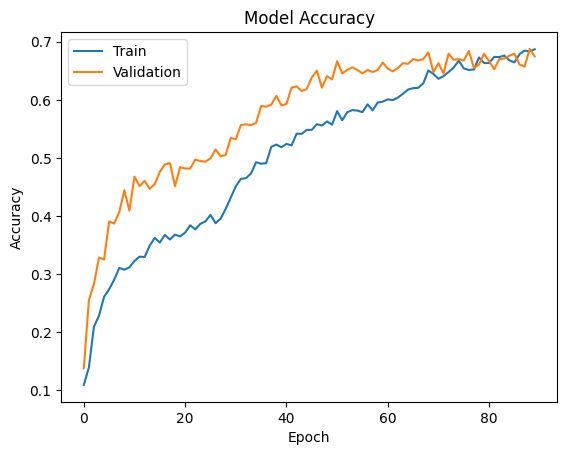

```python
# model1 performance graph
plt.plot(history_1.history['accuracy'])
plt.plot(history_1.history['val_accuracy'])
plt.title('Model Accuracy')
plt.ylabel('Accuracy')
plt.xlabel('Epoch')
plt.legend(['Train', 'Validation'], loc='upper left')
plt.show()
```

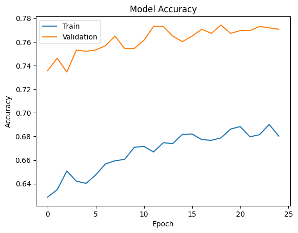

```python
# history_2 plot model accuracy with train and validation dataset
plt.plot(history_2.history['accuracy'])
plt.plot(history_2.history['val_accuracy'])
plt.title('Model Accuracy')
plt.ylabel('Accuracy')
plt.xlabel('Epoch')
plt.legend(['Train', 'Validation'], loc='upper left')
plt.show()
```

As epochs increases the Accuracy has a good progress for val and train data

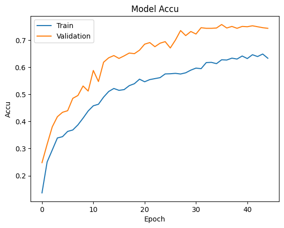

```python
# history_2_1 plot model accuracy with train and validation dataset
plt.plot(history_2_1.history['accuracy'])
plt.plot(history_2_1.history['val_accuracy'])
plt.title('Model Accu')
plt.ylabel('Accu')
plt.xlabel('Epoch')
plt.legend(['Train', 'Validation'], loc='upper left')
plt.show()
```

It looks good on both train and validation and we will more context upon chekcing it with test data

### Model on test data

```python
# get the model outputs against test data
accuracy1 = model1.evaluate(X_test, y_test_encoded, verbose=2)
```

```
15/15 - 0s - loss: 1539.4976 - accuracy: 0.4021 - 462ms/epoch - 31ms/step
```

```python
# get the model outputs against test data
accuracy2 = model2.evaluate(X_test, y_test_encoded, verbose=2)
```

```
15/15 - 0s - loss: 924.7999 - accuracy: 0.3579 - 366ms/epoch - 24ms/step
```

```python
# get the model outputs against test data
accuracy2_1 = model2_1.evaluate(X_test, y_test_encoded, verbose=2)
```

```
15/15 - 0s - loss: 145.6323 - accuracy: 0.5326 - 293ms/epoch - 20ms/step
```

### Confusion Matrix

```python
# setting the ground for confusion matrix
y_pred1=model1.predict(X_test_normalized)
```

```python
y_pred2=model2.predict(X_test_normalized)
```

```python
# this one ran after the above one
y_pred2_1 = model2_1.predict(X_test_normalized)
```

```python
# check the shapes for further validation
y_test.shape, y_test_encoded.shape, y_pred1.shape, y_pred2.shape, y_pred2_1.shape
```

```
((475, 1), (475, 12), (475, 12), (475, 12), (475, 12))
```

#### Model1 confusion matrix

```
y_pred- (475,), y_pred_arg- (475,)
```

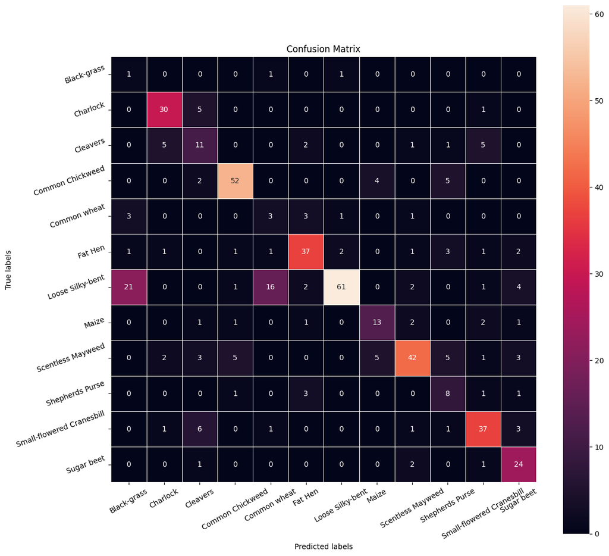

```python
# Get categorical values from test and pred
y_pred1_arg=np.argmax(y_pred1,axis=1)
y_test_arg=np.argmax(y_test_encoded,axis=1)
print(f"y_pred- {y_pred1_arg.shape}, y_pred_arg- {y_test_arg.shape}")

confusion_matrix = tf.math.confusion_matrix(y_pred1_arg,y_test_arg)
f, ax = plt.subplots(figsize=(13, 13))
sns.heatmap(
    confusion_matrix,
    annot=True,
    linewidths=.5,
    fmt="d",
    square=True,
    ax=ax
)
# labels to x and y axes
ax.set_xlabel('Predicted labels');ax.set_ylabel('True labels');
ax.set_title('Confusion Matrix');
ax.xaxis.set_ticklabels(list(label_binarizer.classes_),rotation=30)
ax.yaxis.set_ticklabels(list(label_binarizer.classes_),rotation=20)
plt.show()
```

#### Model2 confusion matrix

```
y_pred2- (475,), y_pred_arg- (475,)
```

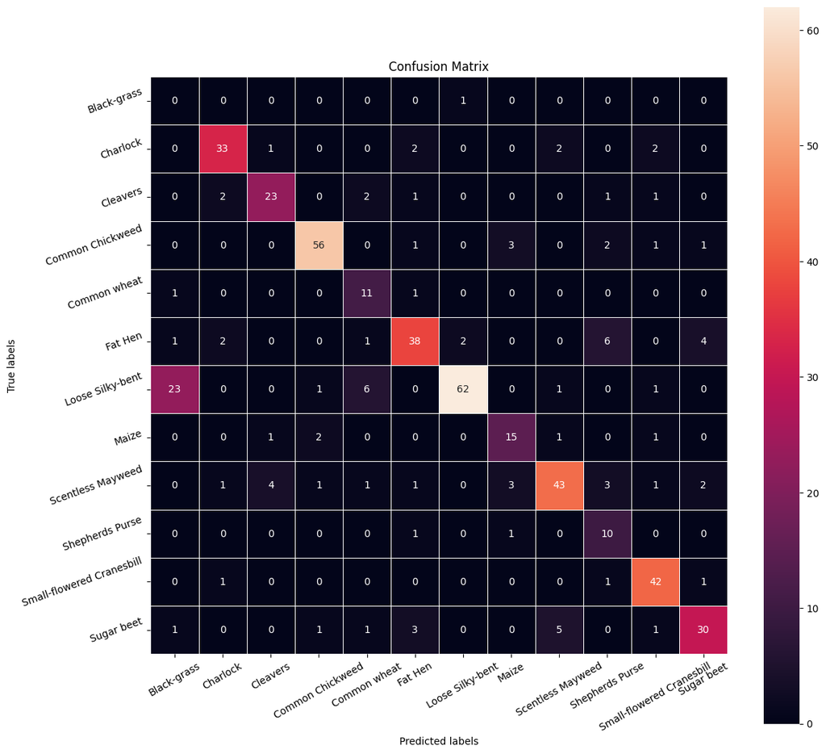

```python
# Get categorical values from test_encoded and pred datasets
y_pred2_arg=np.argmax(y_pred2,axis=1)
y_test_arg=np.argmax(y_test_encoded,axis=1)
print(f"y_pred2- {y_pred2_arg.shape}, y_pred_arg- {y_test_arg.shape}")

confusion_matrix = tf.math.confusion_matrix(y_pred2_arg,y_test_arg)
f, ax = plt.subplots(figsize=(13, 13))
sns.heatmap(
    confusion_matrix,
    annot=True,
    linewidths=.5,
    fmt="d",
    square=True,
    ax=ax
)
# set lables to x and y axes
ax.set_xlabel('Predicted labels');ax.set_ylabel('True labels');
ax.set_title('Confusion Matrix');
ax.xaxis.set_ticklabels(list(label_binarizer.classes_),rotation=30)
ax.yaxis.set_ticklabels(list(label_binarizer.classes_),rotation=20)
plt.show()
```

#### Model2_1 confusion matrix

[output not shown]

[figure not shown]

```python
# Get the categorical values from test and pred data
y_pred2_1_arg=np.argmax(y_pred2_1,axis=1)
y_test_arg=np.argmax(y_test_encoded,axis=1)
print(f"y_pred2- {y_pred2_1arg.shape}, y_pred_arg- {y_test_arg.shape}")

# Code for Confusion Matrix
confusion_matrix = tf.math.confusion_matrix(y_pred2_1_arg,y_test_arg)
f, ax = plt.subplots(figsize=(13, 13))
sns.heatmap(
    confusion_matrix,
    annot=True,
    linewidths=.5,
    fmt="d",
    square=True,
    ax=ax
)
# Set labels to x and y axes
ax.set_xlabel('Predicted labels');ax.set_ylabel('True labels');
ax.set_title('Confusion Matrix');
ax.xaxis.set_ticklabels(list(label_binarizer.classes_),rotation=30)
ax.yaxis.set_ticklabels(list(label_binarizer.classes_),rotation=20)
plt.show()
```